# Homework4

Merve Unal - IE582 - Fall 2018 - 2016702108

**HOMEWORK 4**

```
## Super Learner
```

```
## Version: 2.0-24
```

```
## Package created on 2018-08-10
```

**1.)**

I will model of each data set according to Penalized Regression Approaches, Decision Trees, Support Vector Machines, Random Forests, Stochastic Gradient Boosting. Therefore, in the second part, i slitted to 4 subparts according to each dataset that i mentioned above. I will apply all algorithms you defined for each data set. In the third part, i tuned parameters for each 4 data set and each model that you gave. I know that a for loop should be created and all codes should be included in it but i could not do that. I know my error but the reason why i did not do such way is that at first i did not think such way. Then, in order to change it i did not have enough time In the fourth part, tests are done and some results are presented.

**2.)**

**a.) RESIDENTIAL BUILDING DATA SET**

- Penalized Regression

Since it is regression the measure that i should take into account is mse. Since it is lasso, the value of alpha is 1. I want to make feature selection.

```r
cv_lasso_train_residential_dataset<-cv.glmnet(dm_train_residential_building_dataset_withouty, dm_train_residential_building_dataset_y, alpha = 1, nfolds=10,type.measure = "mse")
cv_lasso_train_residential_dataset
```

```
## $lambda
##  [1] 1236.1052217 1126.2930408 1026.2362713  935.0682695  851.9993816
##  [6]  776.3101048  707.3448548  644.5062875  587.2501253  535.0804427
## [11]  487.5453710  444.2331840  404.7687323  368.8101938  336.0461127
## [16]  306.1927022  278.9913865  254.2065607  231.6235505  211.0467526
## [21]  192.2979408  175.2147218  159.6491288  145.4663402  132.5435115
## [26]  120.7687112  110.0399518  100.2643058   91.3571012   83.2411881
## [31]   75.8462704   69.1082968   62.9689062   57.3749221   52.2778922
## [36]   47.6336683   43.4020245   39.5463083   36.0331232   32.8320399
## [41]   29.9153320   27.2577363   24.8362342   22.6298516   20.6194779
## [46]   18.7877003   17.1186528   15.5978789   14.2122063   12.9496331
## [51]   11.7992234   10.7510129    9.7959225    8.9256798    8.1327470
## [56]    7.4102562    6.7519494    6.1521248    5.6055870    5.1076021
## [61]    4.6538568    4.2404210    3.8637137    3.5204720    3.2077230
## [66]    2.9227577    2.6631080    2.4265248    2.2109590    2.0145435
```

[output cut: 197 more lines]

cv.glmnet helps the user to select yhe most appropriate value for lambda, choosing the number of nfold validation.

```r
# to find the best lambda using cross-validation fit the final model on the training data
cv_bestlambda_train_residential <- glmnet(dm_train_residential_building_dataset_withouty,dm_train_residential_building_dataset_y, alpha=1,lambda=cv_lasso_train_residential_dataset$lambda.min)
coef(cv_bestlambda_train_residential)
```

```
## 109 x 1 sparse Matrix of class "dgCMatrix"
##                               s0
## (Intercept)        -2.857697e+02
## START.YEAR          .
## START.QUARTER       5.542374e+00
## COMPLETION.YEAR     .
## COMPLETION.QUARTER  2.011669e+01
## V.1                -4.398287e+00
## V.2                 4.351972e-02
## V.3                -1.411408e-01
## V.4                 3.827442e-03
## V.5                -2.230067e+00
## V.6                 2.172550e-02
## V.7                 1.985431e+01
## V.8                 1.228700e+00
## V.11                .
## V.12                .
## V.13                .
## V.14                .
## V.15                .
## V.16               -1.607181e-02
## V.17                2.859754e-01
## V.18                1.071334e-02
## V.19                1.768189e-03
## V.20                .
## V.21                .
## V.22                .
## V.23                5.006914e-03
## V.24                1.435801e-02
## V.25                2.706160e-02
## V.26                .
## V.27                .
## V.28                .
## V.29                2.044048e-04
## V.11__1             .
## V.12__1             .
## V.13__1             .
## V.14__1             1.104041e+01
## V.15__1             .
## V.16__1             2.876820e-02
```

[output cut: 56 more lines]

```
## V.16__4             .
## V.17__4             .
## V.18__4             6.492046e-02
## V.19__4             .
## V.20__4             5.930029e+00
## V.21__4             5.520457e-02
## V.22__4             2.424044e-03
## V.23__4             .
## V.24__4             .
## V.25__4             .
## V.26__4             .
## V.27__4             .
## V.28__4             .
## V.29__4             .
## V.10                1.195177e+00
```

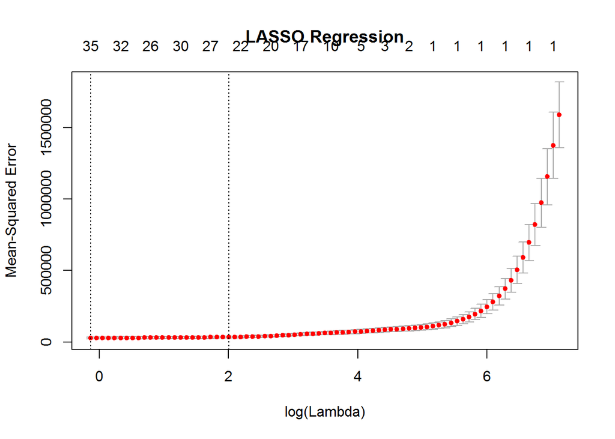

```r
plot(cv_lasso_train_residential_dataset,main="LASSO Regression")
```

Figure 1: LASSO Regression

- Support Vector Machines

```
##
## Call:
## svm(formula = dm_train_residential_building_dataset_y ~ ., data = dm_residential,
##     kernel = "radial", cross = 10)
##
##
## Parameters:
##    SVM-Type:  eps-regression
##  SVM-Kernel:  radial
##        cost:  1
##       gamma:  0.009174312
##     epsilon:  0.1
##
##
## Number of Support Vectors:  136
```

```
##
## Call:
## svm(formula = dm_train_residential_building_dataset_y ~ ., data = dm_residential,
##     kernel = "polynomial", cross = 10)
##
##
## Parameters:
##    SVM-Type:  eps-regression
##  SVM-Kernel:  polynomial
##        cost:  1
##      degree:  3
##       gamma:  0.009174312
##      coef.0:  0
##     epsilon:  0.1
##
##
## Number of Support Vectors:  176
```

Cross validation was done. The first one is radial kernel. The second is polynomial kernel.

- Decision trees

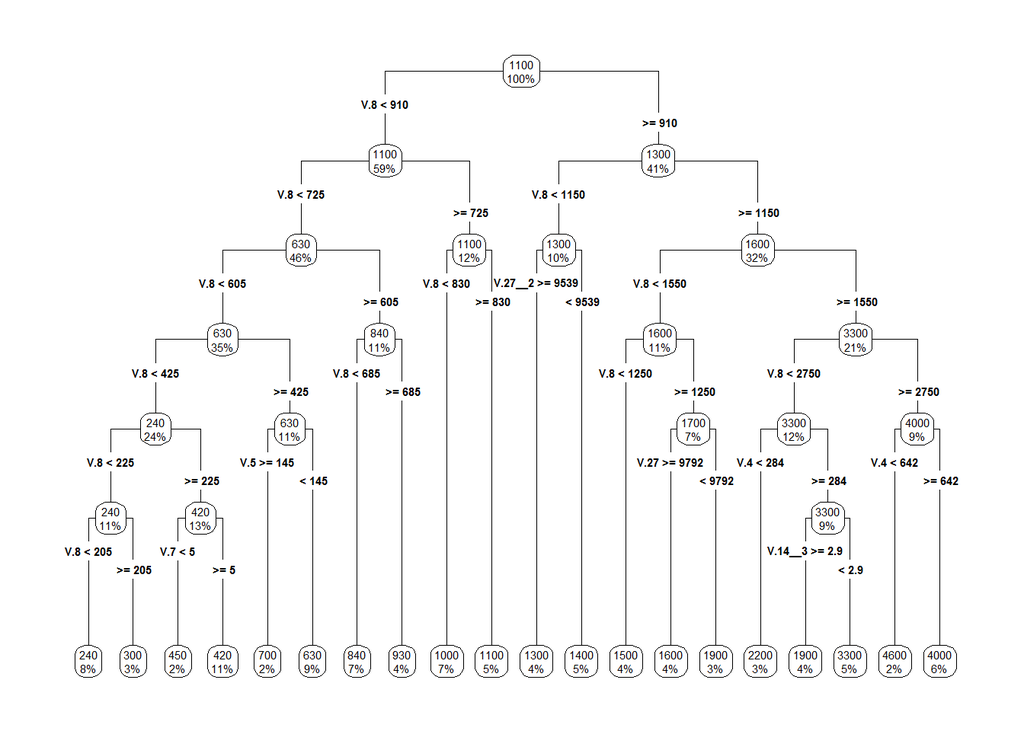

- Random Forest

```
##
## Call:
##  randomForest(formula = dm_train_residential_building_dataset_y ~      ., data = train_residential_building_dataset, nodesize = 5)
##                Type of random forest: regression
##                      Number of trees: 500
## No. of variables tried at each split: 36
##
##           Mean of squared residuals: 39504.85
##                     % Var explained: 97.53
```

- GBM

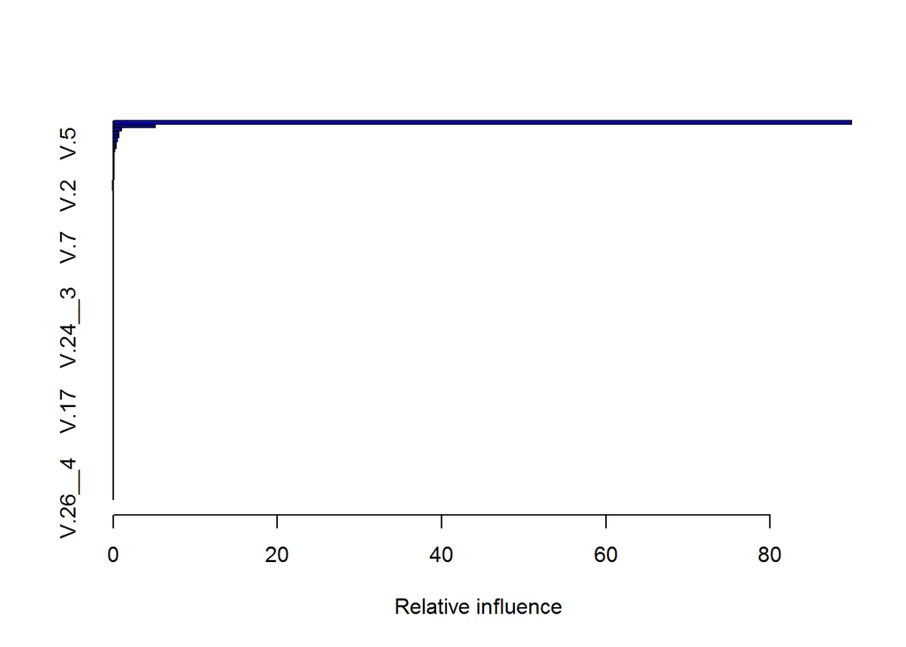

```
##                                   var      rel.inf
## V.9                               V.9 8.989995e+01
## V.8                               V.8 5.125713e+00
## V.4                               V.4 9.996442e-01
## V.10                             V.10 7.027223e-01
## V.1                               V.1 6.300632e-01
## V.19__2                       V.19__2 4.650292e-01
## V.5                               V.5 3.468361e-01
## V.19__3                       V.19__3 3.155095e-01
## V.23                             V.23 1.504790e-01
## V.18__3                       V.18__3 1.126634e-01
## V.18__1                       V.18__1 1.048822e-01
## V.16__2                       V.16__2 1.026858e-01
## V.19__1                       V.19__1 6.187848e-02
## V.11                             V.11 6.046564e-02
## V.28__1                       V.28__1 5.703427e-02
## V.19__4                       V.19__4 5.506344e-02
## V.29__2                       V.29__2 5.350625e-02
## V.14                             V.14 4.674728e-02
## V.14__1                       V.14__1 4.334965e-02
## V.16__3                       V.16__3 4.215892e-02
## V.6                               V.6 4.023899e-02
## V.2                               V.2 3.973727e-02
## V.28__3                       V.28__3 3.780654e-02
## V.23__1                       V.23__1 3.720802e-02
## V.18__2                       V.18__2 3.568884e-02
## V.16__4                       V.16__4 2.953868e-02
## V.3                               V.3 2.714647e-02
## V.11__1                       V.11__1 2.617503e-02
## V.11__2                       V.11__2 2.566788e-02
## V.11__4                       V.11__4 2.264939e-02
## V.24                             V.24 2.034191e-02
## V.14__2                       V.14__2 2.020250e-02
## V.28__2                       V.28__2 1.968984e-02
## COMPLETION.YEAR       COMPLETION.YEAR 1.840144e-02
## V.16                             V.16 1.599038e-02
## V.19                             V.19 1.501574e-02
## V.7                               V.7 1.402428e-02
## V.23__3                       V.23__3 1.301778e-02
## V.20__4                       V.20__4 1.234962e-02
```

[output cut: 55 more lines]

```
## V.17__1                       V.17__1 0.000000e+00
## V.26__1                       V.26__1 0.000000e+00
## V.12__2                       V.12__2 0.000000e+00
## V.15__2                       V.15__2 0.000000e+00
## V.17__2                       V.17__2 0.000000e+00
## V.26__2                       V.26__2 0.000000e+00
## V.12__3                       V.12__3 0.000000e+00
## V.15__3                       V.15__3 0.000000e+00
## V.17__3                       V.17__3 0.000000e+00
## V.26__3                       V.26__3 0.000000e+00
## V.12__4                       V.12__4 0.000000e+00
## V.15__4                       V.15__4 0.000000e+00
## V.17__4                       V.17__4 0.000000e+00
## V.25__4                       V.25__4 0.000000e+00
## V.26__4                       V.26__4 0.000000e+00
```

**b.) SPORT ARTICLES**

Data partition for train and test.The set.seed() method is used to make our work replicable.During partitioning of data, it splits randomly but if our readers will pass the same value in the set.seed() method.A method is used called as createDataPartition() for partitioning our data into train and test set.

```
## [1] FALSE
```

- PENALIZED REGRESSION WITH LASSO

```
## $lambda
##  [1] 0.2591408715 0.2361195107 0.2151433042 0.1960305660 0.1786157508
##  [6] 0.1627480198 0.1482899343 0.1351162652 0.1231129086 0.1121758972
## [11] 0.1022104996 0.0931304006 0.0848569525 0.0773184947 0.0704497327
## [16] 0.0641911726 0.0584886058 0.0532926393 0.0485582681 0.0442444854
## [21] 0.0403139272 0.0367325491 0.0334693306 0.0304960076 0.0277868263
## [26] 0.0253183212 0.0230691114 0.0210197151 0.0191523815 0.0174509367
## [31] 0.0159006436 0.0144880743 0.0132009937 0.0120282538 0.0109596969
## [36] 0.0099860676 0.0090989329 0.0082906088 0.0075540939 0.0068830091
## [41] 0.0062715415 0.0057143950 0.0052067439 0.0047441912 0.0043227303
## [46] 0.0039387108 0.0035888066 0.0032699869 0.0029794903 0.0027148006
## [51] 0.0024736252 0.0022538752 0.0020536471 0.0018712068 0.0017049739
## [56] 0.0015535087 0.0014154993 0.0012897502 0.0011751724 0.0010707733
## [61] 0.0009756488 0.0008889748 0.0008100007 0.0007380425 0.0006724768
## [66] 0.0006127359 0.0005583021 0.0005087041 0.0004635122 0.0004223351
```

[output cut: 157 more lines]

- DECISION TREES

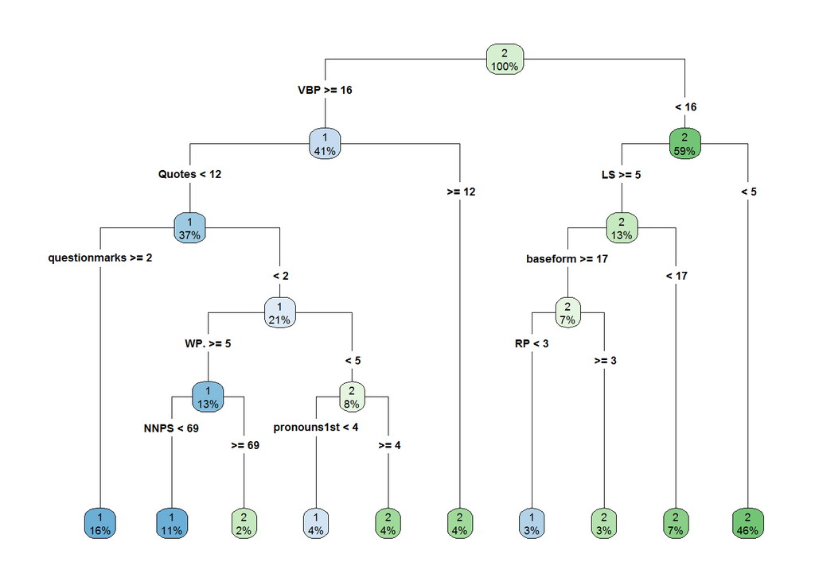

**c.)LAS VEGAS DATA SET**

- DECISION TREE

```
## Classes 'tbl_df', 'tbl' and 'data.frame':    504 obs. of  20 variables:
##  $ User country     : Factor w/ 47 levels "Australia","Belgium",..: 47 47 47 45 4 4 45 47 18 4 ...
##  $ Nr. reviews      : num  11 119 36 14 5 31 45 2 24 12 ...
##  $ Nr. hotel reviews: num  4 21 9 7 5 8 12 1 3 7 ...
##  $ Helpful votes    : num  13 75 25 14 2 27 46 4 8 11 ...
##  $ Score            : Factor w/ 5 levels "1","2","3","4",..: 5 3 5 4 4 3 4 4 4 3 ...
##  $ Period of stay   : Factor w/ 4 levels "Dec-Feb","Jun-Aug",..: 1 1 3 3 3 3 3 3 3 3 ...
##  $ Traveler type    : Factor w/ 5 levels "Business","Couples",..: 4 1 3 4 5 2 2 3 4 3 ...
##  $ Pool             : Factor w/ 2 levels "NO","YES": 1 1 1 1 1 1 1 1 1 1 ...
##  $ Gym              : Factor w/ 2 levels "NO","YES": 2 2 2 2 2 2 2 2 2 2 ...
##  $ Tennis court     : Factor w/ 2 levels "NO","YES": 1 1 1 1 1 1 1 1 1 1 ...
##  $ Spa              : Factor w/ 2 levels "NO","YES": 1 1 1 1 1 1 1 1 1 1 ...
##  $ Casino           : Factor w/ 2 levels "NO","YES": 2 2 2 2 2 2 2 2 2 2 ...
##  $ Free internet    : Factor w/ 2 levels "NO","YES": 2 2 2 2 2 2 2 2 2 2 ...
##  $ Hotel name       : Factor w/ 21 levels "Bellagio Las Vegas",..: 3 3 3 3 3 3 3 3 3 3 ...
##  $ Hotel stars      : num  3 3 3 3 3 3 3 3 3 3 ...
##  $ Nr. rooms        : num  3773 3773 3773 3773 3773 ...
##  $ User continent   : Factor w/ 6 levels "Africa","Asia",..: 4 4 4 3 4 4 3 4 2 4 ...
##  $ Member years     : num  9 3 2 6 7 2 4 0 3 5 ...
##  $ Review month     : Factor w/ 12 levels "April","August",..: 5 5 4 4 8 8 1 1 9 9 ...
##  $ Review weekday   : Factor w/ 7 levels "Friday","Monday",..: 5 1 3 1 6 6 1 6 3 6 ...
```

```
## n= 354
##
## node), split, n, loss, yval, (yprob)
##       * denotes terminal node
##
## 1) root 354 195 5 (0.023 0.059 0.14 0.32 0.45) *
```

- Penalized regression

```
## $lambda
##  [1] 0.2512473178 0.2289271986 0.2085899372 0.1900593821 0.1731750305
##  [6] 0.1577906381 0.1437729527 0.1310005598 0.1193628312 0.1087589662
## [11] 0.0990971194 0.0902936045 0.0822721695 0.0749633367 0.0683038005
## [16] 0.0622358791 0.0567070152 0.0516693202 0.0470791602 0.0428967774
## [21] 0.0390859459 0.0356136582 0.0324498390 0.0295670847 0.0269404264
## [26] 0.0245471132 0.0223664153 0.0203794446 0.0185689909 0.0169193729
## [31] 0.0154163025 0.0140467607 0.0127988852 0.0116618675 0.0106258593
## [36] 0.0096818873 0.0088217751 0.0080380729 0.0073239927 0.0066733493
## [41] 0.0060805074 0.0055403319 0.0050481440 0.0045996808 0.0041910579
## [46] 0.0038187358 0.0034794899 0.0031703816 0.0028887336 0.0026321065
## [51] 0.0023982774 0.0021852211 0.0019910920 0.0018142089 0.0016530396
## [56] 0.0015061881 0.0013723825 0.0012504638 0.0011393761 0.0010381570
## [61] 0.0009459300 0.0008618962 0.0007853277 0.0007155614 0.0006519929
## [66] 0.0005940716 0.0005412959 0.0004932087 0.0004493934 0.0004094705
```

[output cut: 156 more lines]

- SVM

```
##
## Call:
## svm(formula = Score ~ ., data = training_lasvegas, kernel = "radial",
##     cross = 10)
##
##
## Parameters:
##    SVM-Type:  eps-regression
##  SVM-Kernel:  radial
##        cost:  1
##       gamma:  0.05263158
##     epsilon:  0.1
##
##
## Number of Support Vectors:  326
```

```
##
## Call:
## svm(formula = Score ~ ., data = training_lasvegas, kernel = "polynomial",
##     degree = 3, cost = 1, cross = 10)
##
##
## Parameters:
##    SVM-Type:  eps-regression
##  SVM-Kernel:  polynomial
##        cost:  1
##      degree:  3
##       gamma:  0.05263158
##      coef.0:  0
##     epsilon:  0.1
##
##
## Number of Support Vectors:  336
```

- Random Forest

```
##
## Call:
##  randomForest(formula = Score ~ ., data = training_lasvegas, nodesize = 5)
##                Type of random forest: classification
##                      Number of trees: 500
## No. of variables tried at each split: 4
##
##         OOB estimate of  error rate: 56.21%
## Confusion matrix:
##   1 2 3  4   5 class.error
## 1 0 1 1  2   4   1.0000000
## 2 0 0 1  7  13   1.0000000
## 3 0 0 3 25  23   0.9411765
## 4 1 0 4 42  68   0.6347826
## 5 0 2 4 43 110   0.3081761
```

- GBM

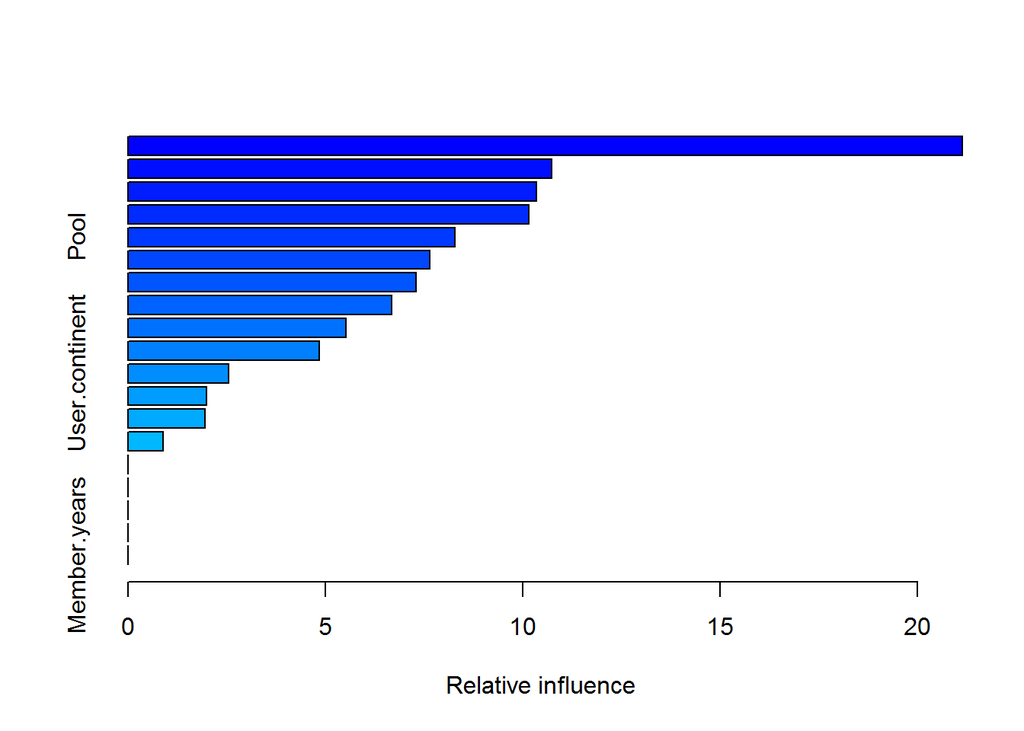

```
##                                 var    rel.inf
## Nr..reviews             Nr..reviews 21.1315831
## Hotel.stars             Hotel.stars 10.7363235
## Nr..rooms                 Nr..rooms 10.3438592
## Traveler.type         Traveler.type 10.1494103
## Pool                           Pool  8.2757410
## Free.internet         Free.internet  7.6476329
## Review.weekday       Review.weekday  7.2926399
## Review.month           Review.month  6.6742226
## Helpful.votes         Helpful.votes  5.5155303
## Hotel.name               Hotel.name  4.8544148
## User.continent       User.continent  2.5428206
## User.country           User.country  1.9941007
## Nr..hotel.reviews Nr..hotel.reviews  1.9514146
## Period.of.stay       Period.of.stay  0.8903065
## Gym                             Gym  0.0000000
## Tennis.court           Tennis.court  0.0000000
## Spa                             Spa  0.0000000
## Casino                       Casino  0.0000000
## Member.years           Member.years  0.0000000
```

**d.) Parkinsons**

- Random forest

Class imbalance problem

```
##
## Call:
##  randomForest(formula = status ~ ., data = training_parkinsons,      nodesize = 5)
##                Type of random forest: classification
##                      Number of trees: 500
## No. of variables tried at each split: 4
##
##         OOB estimate of  error rate: 8.76%
## Confusion matrix:
##    0   1 class.error
## 0 24  10  0.29411765
## 1  2 101  0.01941748
```

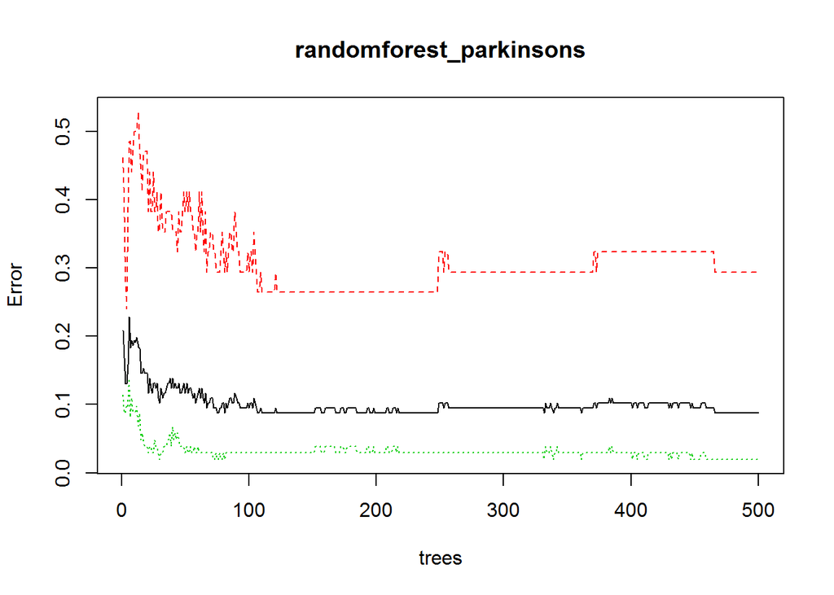

- GBM

```
## gbm(formula = training_parkinsons$status ~ ., distribution = "bernoulli",
##     data = training_parkinsons, n.trees = 10, interaction.depth = 5,
##     n.minobsinnode = 5, shrinkage = 0.1, bag.fraction = 0.5)
## A gradient boosted model with bernoulli loss function.
## 10 iterations were performed.
## There were 22 predictors of which 0 had non-zero influence.
```

- Penalized regression

```
## 23 x 1 sparse Matrix of class "dgCMatrix"
##                            s0
## (Intercept)      -0.542140819
## MDVP.Fo.Hz.      -0.005339076
## MDVP.Fhi.Hz.     -0.003482867
## MDVP.Flo.Hz.      .
## MDVP.Jitter...    .
## MDVP.Jitter.Abs.  .
## MDVP.RAP          .
## MDVP.PPQ          .
## Jitter.DDP        .
## MDVP.Shimmer      .
## MDVP.Shimmer.dB.  .
## Shimmer.APQ3      .
## Shimmer.APQ5      .
## MDVP.APQ         28.158854202
## Shimmer.DDA       .
## NHR               .
## HNR               .
## RPDE             -1.169905036
## DFA               .
## spread1           0.603450969
## spread2           2.325819194
## D2                1.827964781
## PPE              13.327490248
```

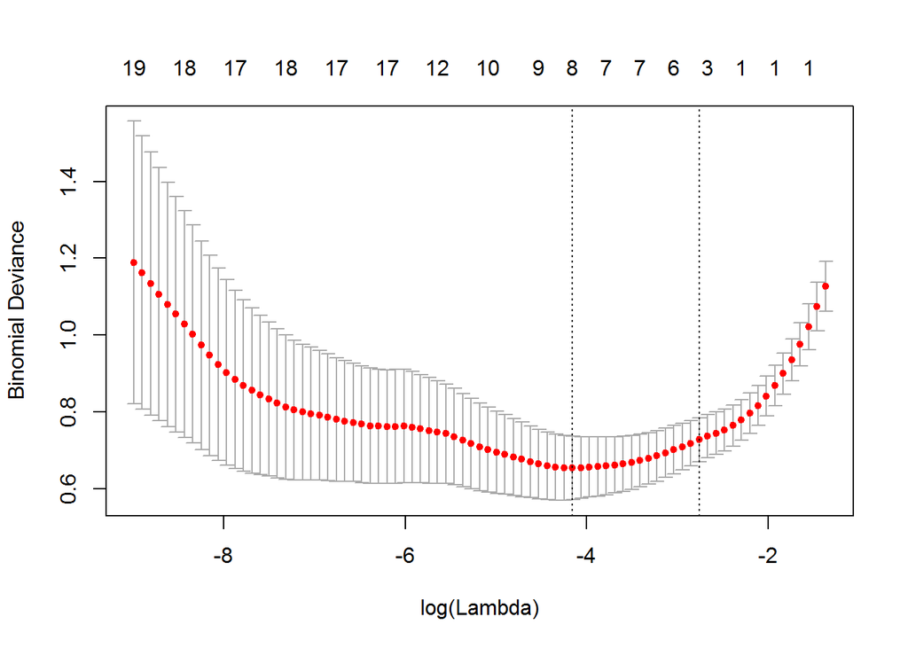

- DECISION TREES

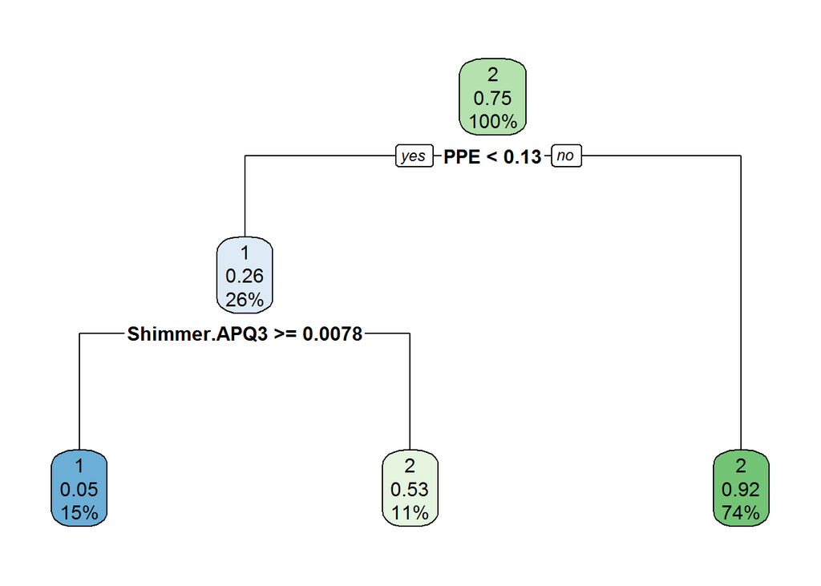

- SVM-RADIAL

```
##
## Call:
## svm(formula = status ~ ., data = training_parkinsons, kernel = "radial",
##     cross = 10)
##
##
## Parameters:
##    SVM-Type:  C-classification
##  SVM-Kernel:  radial
##        cost:  1
##       gamma:  0.04545455
##
## Number of Support Vectors:  67
```

- SVM-POLYNOMIAL

```
##
## Call:
## svm(formula = status ~ ., data = training_parkinsons, kernel = "polynomial",
##     degree = 3, cost = 1, cross = 10)
##
##
## Parameters:
##    SVM-Type:  C-classification
##  SVM-Kernel:  polynomial
##        cost:  1
##      degree:  3
##       gamma:  0.04545455
##      coef.0:  0
##
## Number of Support Vectors:  59
```

**3.)**

**a.) RESIDENTIAL BUILDING DATA SET**

- PENALIZED REGRESSION - LASSO

```
## Quantile Regression with LASSO penalty
##
## 299 samples
## 108 predictors
##
## No pre-processing
## Resampling: Bootstrapped (25 reps)
## Summary of sample sizes: 299, 299, 299, 299, 299, 299, ...
## Resampling results across tuning parameters:
##
##   lambda  RMSE      Rsquared   MAE
##   2       206.1153  0.9748649  112.3796
##   3       205.4412  0.9749283  113.7319
##   4       206.5646  0.9747230  113.2404
##   5       206.1456  0.9748578  112.4455
##
## RMSE was used to select the optimal model using the smallest value.
## The final value used for the model was lambda = 3.
```

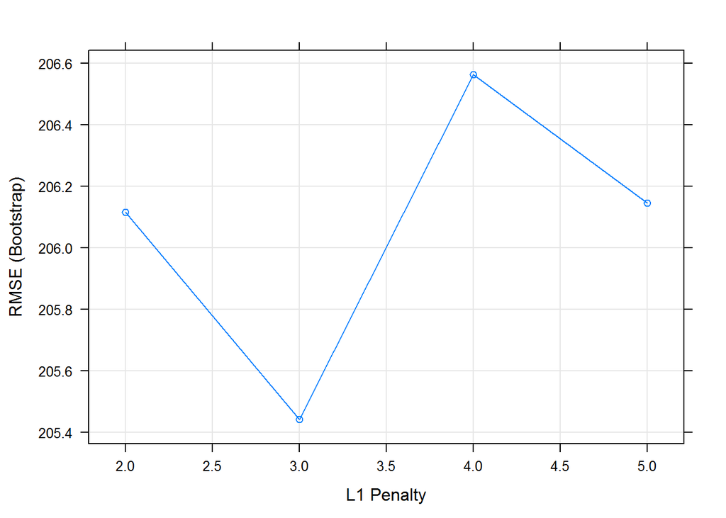

- Support Vector Machines

```
##
## Parameter tuning of 'svm':
##
## - sampling method: 10-fold cross validation
##
## - best parameters:
##  cost
##    16
##
## - best performance: 76040.03
```

```
##
## Parameter tuning of 'svm':
##
## - sampling method: 10-fold cross validation
##
## - best parameters:
##  cost
##    16
##
## - best performance: 76040.03
##
## - Detailed performance results:
##   cost    error dispersion
## 1    4 92924.94   81161.68
## 2    8 79359.59   74630.92
## 3   16 76040.03   74806.93
```

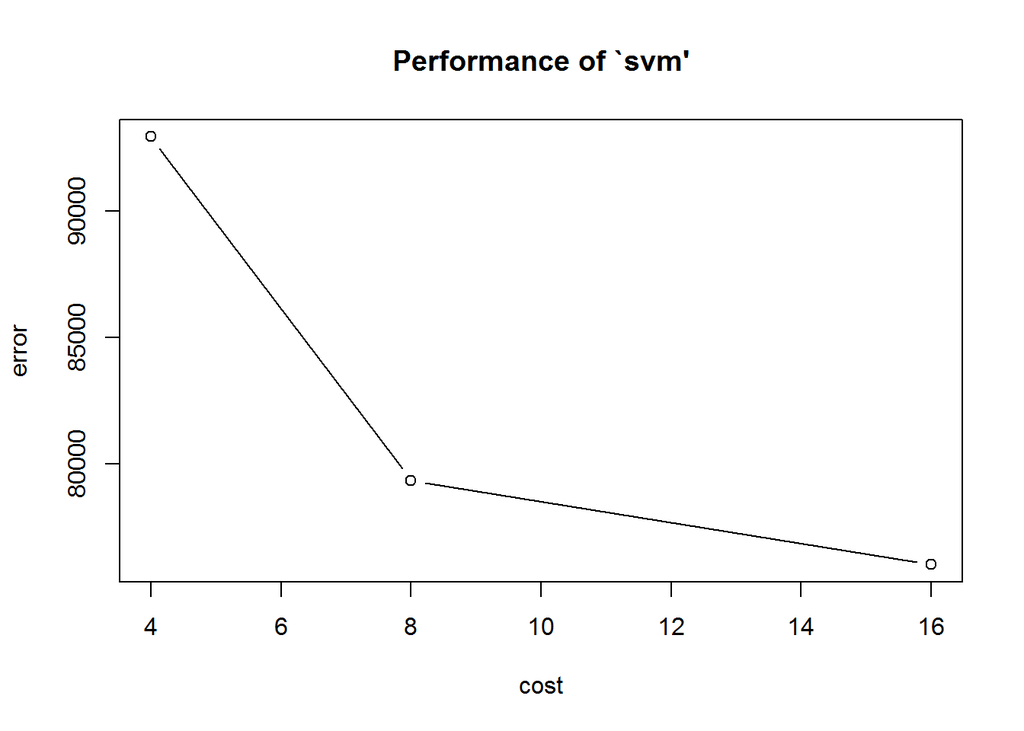

- DECISION TREES

```
##
## Parameter tuning of 'rpart.wrapper':
##
## - sampling method: 10-fold cross validation
##
## - best parameters:
##  minbucket   cp
##          2 0.01
##
## - best performance: 134644.9
```

```
##
## Parameter tuning of 'rpart.wrapper':
##
## - sampling method: 10-fold cross validation
##
## - best parameters:
##  minbucket   cp
##          2 0.01
##
## - best performance: 134644.9
##
## - Detailed performance results:
##   minbucket   cp    error dispersion
## 1         2 0.01 134644.9   83533.74
## 2         3 0.01 134644.9   83533.74
## 3         4 0.01 134644.9   83533.74
## 4         5 0.01 134644.9   83533.74
```

- RANDOM FOREST

```
##                 Length Class      Mode
## call              4    -none-     call
## type              1    -none-     character
## predicted       299    -none-     numeric
## mse             500    -none-     numeric
## rsq             500    -none-     numeric
## oob.times       299    -none-     numeric
## importance      108    -none-     numeric
## importanceSD      0    -none-     NULL
## localImportance   0    -none-     NULL
## proximity         0    -none-     NULL
## ntree             1    -none-     numeric
## mtry              1    -none-     numeric
## forest           11    -none-     list
## coefs             0    -none-     NULL
## y               299    -none-     numeric
## test              0    -none-     NULL
## inbag             0    -none-     NULL
## xNames          108    -none-     character
## problemType       1    -none-     character
## tuneValue         1    data.frame list
## obsLevels         1    -none-     logical
## param             0    -none-     list
```

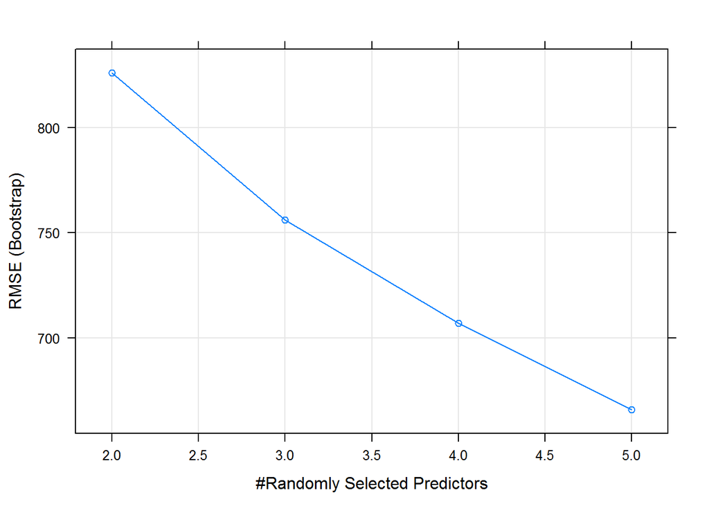

- Stochastic Gradient Boosting

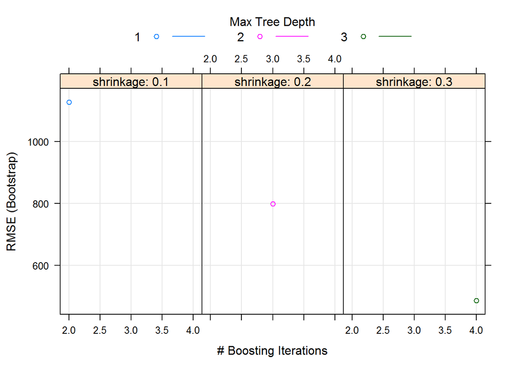

**b.) SPORT ARTICLES**

- PENALIZED REGRESSION - LASSO

Since it lasted too long and then the system automatically closes, i stopped the code. You acn find the code that i could not work below.

lasso_sportarticles<-caret::train(obj_subj~.,data=training_dt_sportarticles,preProcess=c(“scale”),method=“PenalizedLDA”,tuneGrid=mygrid,trainControl(method = “cv”))

- SUPPORT VECTOR MACHINES - POLYNOMIAL

Since it lasted too long and then the system automatically closes, i stopped the code. You acn find the code that i could not work below.

tune__sport_svmpoly<-caret::train(obj_subj~.,data=training_dt_sportarticles,method=‘svmPoly’,tuneGrid=mygrid)

- SUPPORT VECTOR MACHINES - RADIAL

```
##
## Parameter tuning of 'svm':
##
## - sampling method: 10-fold cross validation
##
## - best parameters:
##  cost
##     4
##
## - best performance: 0.1855131
##
## - Detailed performance results:
##   cost     error dispersion
## 1    4 0.1855131 0.03893798
## 2    8 0.1883501 0.04104731
## 3   16 0.2097384 0.04732114
```

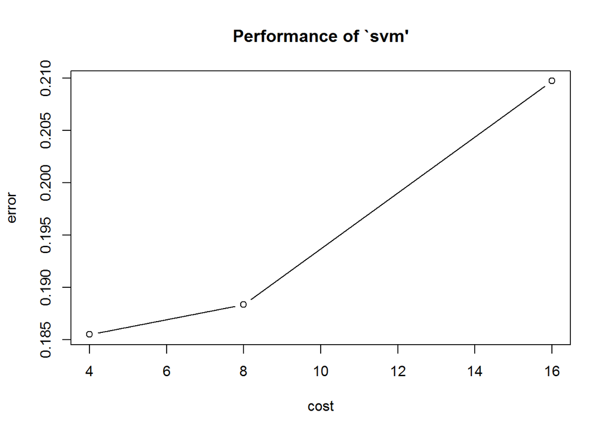

- DECISION TREES

```
##
## Parameter tuning of 'rpart.wrapper':
##
## - sampling method: 10-fold cross validation
##
## - best parameters:
##  minbucket   cp
##          4 0.01
##
## - best performance: 0.185493
```

```
##
## Parameter tuning of 'rpart.wrapper':
##
## - sampling method: 10-fold cross validation
##
## - best parameters:
##  minbucket   cp
##          4 0.01
##
## - best performance: 0.185493
##
## - Detailed performance results:
##   minbucket   cp     error dispersion
## 1         2 0.01 0.1954527 0.03879901
## 2         3 0.01 0.1926358 0.04076820
## 3         4 0.01 0.1854930 0.03388701
## 4         5 0.01 0.1883300 0.02936646
```

- RANDOM FOREST

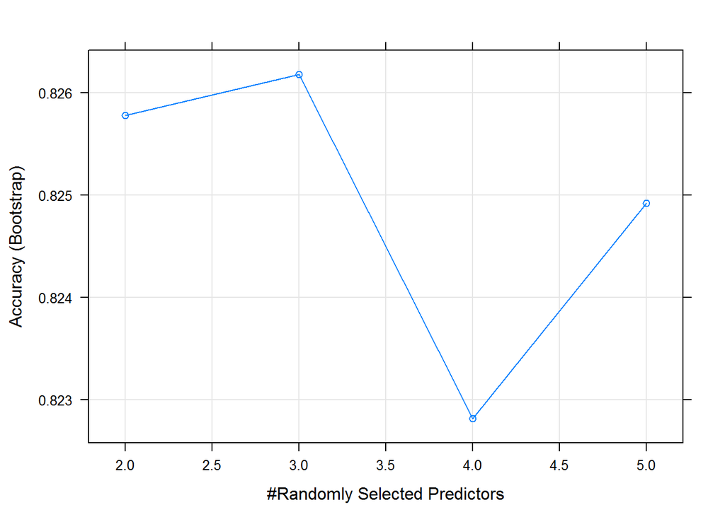

- Stochastic Gradient Boosting

Since it lasted too long and then the system automatically closes, i stopped the code. You acn find the code that i could not work below. mygrid<-data.frame(n.trees=c(2,3,4),interaction.depth=c(1,2,3),shrinkage=c(0.1,0.2,0.3),n.minobsinnode=c(10,10,10)) sgb_sport<-caret::train(obj_subj~.,data=training_dt_sportarticles,method=“gbm”,tuneGrid=mygrid) sgb_sport plot(sgb_sport)

- Ensemble

**c.) LAS VEGAS**

- PENALIZED REGRESSION - LASSO

Code is running but no answer is given. Time lasting is so long so the code is below.

lasso_lasvegas<-caret::train(Score~.,data=training_lasvegas,preProcess=c(“scale”),method=“pda”,tuneGrid=mygrid,trainControl(method = “cv”))

- SVM-RADIAL

```r
set.seed(3)
tune_svm_lasvegas_radial<-tune.svm(Score~., data =training_lasvegas_dt, cost = 2^(2:4))
summary(tune_svm_lasvegas_radial)
```

```
##
## Parameter tuning of 'svm':
##
## - sampling method: 10-fold cross validation
##
## - best parameters:
##  cost
##     4
##
## - best performance: 0.5438889
##
## - Detailed performance results:
##   cost     error dispersion
## 1    4 0.5438889 0.08338669
## 2    8 0.5554762 0.09717925
## 3   16 0.5721429 0.11325128
```

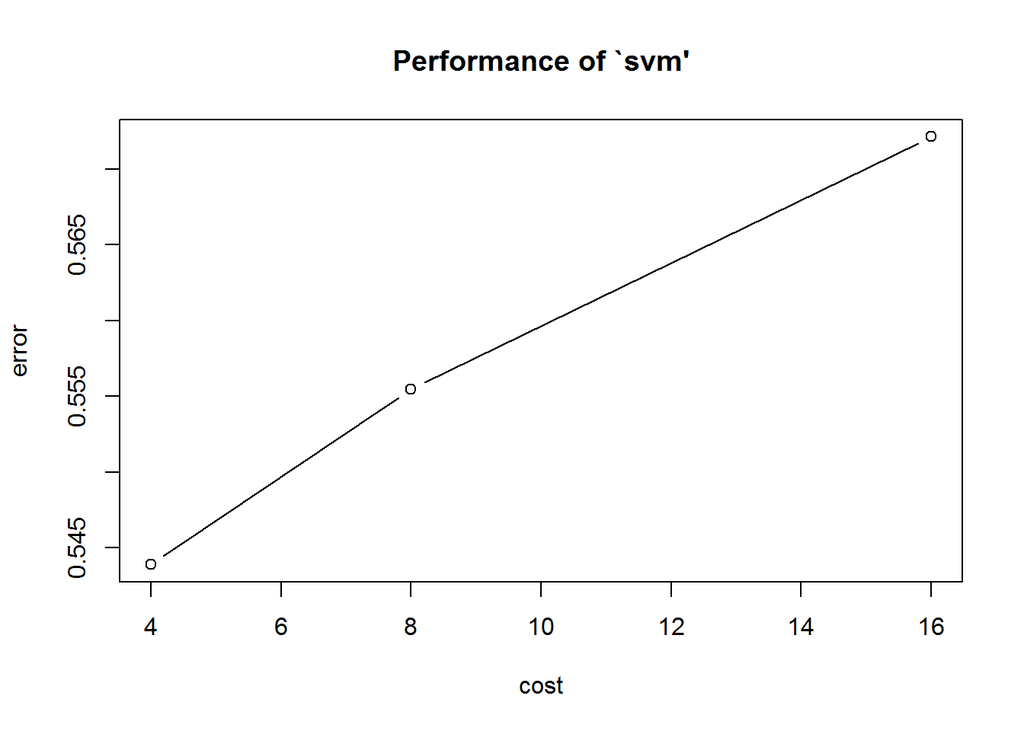

```r
plot(tune_svm_lasvegas_radial)
```

As you see, the least error is 0.545,which cost value is 4 in there.

- SVM-POLYNOMIAL

Since it lasted too long and then the system automatically closes, i stopped the code. You acn find the code that i could not work below.

mygrid<-data.frame(C=c(2,3,4), degree=c(1,2,3),scale=c(1,2,3)) set.seed(42) training_lasvegas_dt<-data.table(training_lasvegas) poly_lasvegas<-caret::train(Score~.,data=training_lasvegas_dt,preProcess=c(“scale”),method = ‘svmPoly’,tuneGrid=mygrid,trainControl(method = “cv”))

- DECISION TREES

```
##
## Parameter tuning of 'rpart.wrapper':
##
## - sampling method: 10-fold cross validation
##
## - best parameters:
##  minbucket   cp
##          3 0.01
##
## - best performance: 0.5578571
```

```
##
## Parameter tuning of 'rpart.wrapper':
##
## - sampling method: 10-fold cross validation
##
## - best parameters:
##  minbucket   cp
##          3 0.01
##
## - best performance: 0.5578571
##
## - Detailed performance results:
##   minbucket   cp     error dispersion
## 1         2 0.01 0.5607143 0.11971433
## 2         3 0.01 0.5578571 0.12711878
## 3         4 0.01 0.5722222 0.09357528
## 4         5 0.01 0.5836508 0.09557861
## 5         6 0.01 0.5891270 0.09281459
## 6         7 0.01 0.5805556 0.09933660
## 7         8 0.01 0.5807937 0.09053249
```

- RANDOM FORESTS

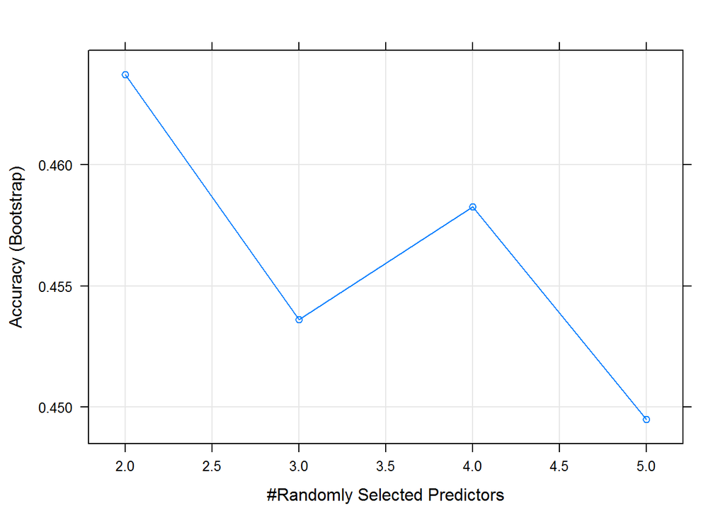

- SGB

```
## Stochastic Gradient Boosting
##
## 353 samples
##  19 predictor
##   5 classes: '1', '2', '3', '4', '5'
##
## No pre-processing
## Resampling: Bootstrapped (25 reps)
## Summary of sample sizes: 353, 353, 353, 353, 353, 353, ...
## Resampling results across tuning parameters:
##
##   shrinkage  interaction.depth  n.minobsinnode  Accuracy   Kappa
##   0.1        1                  10              0.4586327  0.07418185
##   0.2        2                  11              0.4434265  0.09340873
##   0.3        3                  12              0.4395167  0.10368696
##
## Tuning parameter 'n.trees' was held constant at a value of 2
## Accuracy was used to select the optimal model using the largest value.
## The final values used for the model were n.trees = 2, interaction.depth
##  = 1, shrinkage = 0.1 and n.minobsinnode = 10.
```

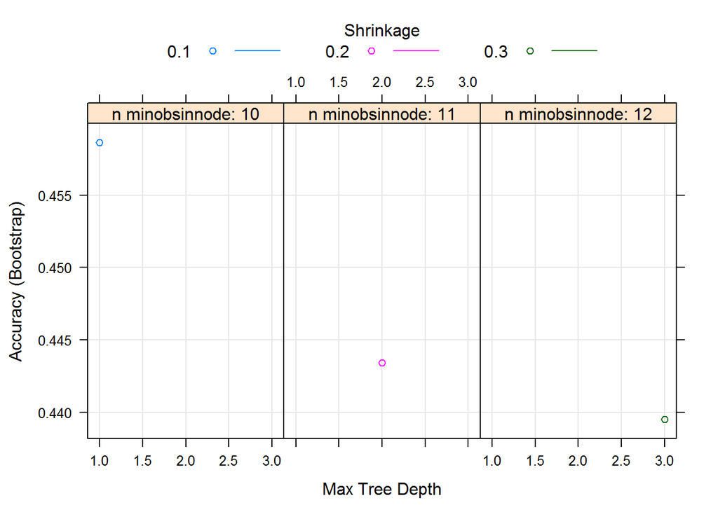

**d.) Parkinsons**

This is class imbalance problem, whose ratio is nearly 1:3.

```
##
##   0   1
##  48 147
```

```
##
##         0         1
## 0.2461538 0.7538462
```

```
##
##   2   1
## 103  97
```

CONVERT THE IMBALANCED DATA SET TO BALANCED DATA SET

- PENALIZED REGRESSION-LASSO

```
## Penalized Discriminant Analysis
##
## 200 samples
##  22 predictor
##   2 classes: '2', '1'
##
## No pre-processing
## Resampling: Bootstrapped (25 reps)
## Summary of sample sizes: 200, 200, 200, 200, 200, 200, ...
## Resampling results across tuning parameters:
##
##   lambda  Accuracy   Kappa
##   2       0.7978294  0.5960588
##   3       0.7972656  0.5951586
##   4       0.7972085  0.5946110
##   5       0.7955534  0.5910059
##
## Accuracy was used to select the optimal model using the largest value.
## The final value used for the model was lambda = 2.
```

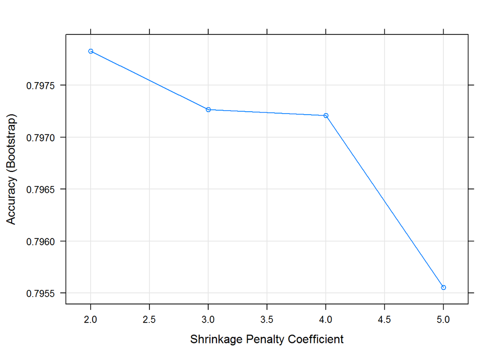

- SVM-RADIAL

```
##
## Parameter tuning of 'svm':
##
## - sampling method: 10-fold cross validation
##
## - best parameters:
##  cost
##    16
##
## - best performance: 0.04
##
## - Detailed performance results:
##   cost error dispersion
## 1    4 0.060 0.03162278
## 2    8 0.045 0.03689324
## 3   16 0.040 0.03944053
```

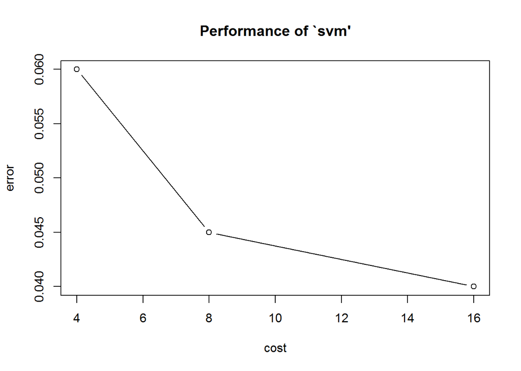

- SVM-POLYNOMIAL

Since it lasted too long and then the system automatically closes, i stopped the code. You acn find the code that i could not work below.

mygrid<-data.frame(C=c(2,3,4), degree=c(1,2,3),scale=c(1,2,3)) set.seed(42) poly_parkinsons<-caret::train(status~.,data=data_balanced_over,preProcess=c(“scale”),method = ‘svmPoly’,tuneGrid=mygrid,trainControl(method = “cv”))

- DECISION TREES

```
##
## Parameter tuning of 'rpart.wrapper':
##
## - sampling method: 10-fold cross validation
##
## - best parameters:
##  minbucket   cp
##          3 0.01
##
## - best performance: 0.115
```

```
##
## Parameter tuning of 'rpart.wrapper':
##
## - sampling method: 10-fold cross validation
##
## - best parameters:
##  minbucket   cp
##          3 0.01
##
## - best performance: 0.115
##
## - Detailed performance results:
##   minbucket   cp error dispersion
## 1         2 0.01 0.120 0.08232726
## 2         3 0.01 0.115 0.07835106
## 3         4 0.01 0.130 0.08232726
## 4         5 0.01 0.130 0.08232726
## 5         6 0.01 0.120 0.07888106
## 6         7 0.01 0.120 0.07888106
## 7         8 0.01 0.120 0.07149204
```

- RANDOM FOREST

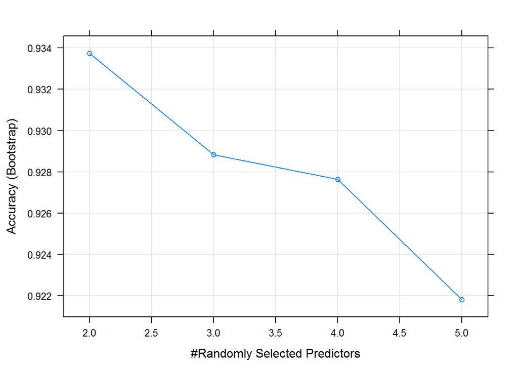

- SGB

```
## Stochastic Gradient Boosting
##
## 200 samples
##  22 predictor
##   2 classes: '2', '1'
##
## No pre-processing
## Resampling: Bootstrapped (25 reps)
## Summary of sample sizes: 200, 200, 200, 200, 200, 200, ...
## Resampling results across tuning parameters:
##
##   shrinkage  interaction.depth  n.minobsinnode  Accuracy   Kappa
##   0.1        1                  10              0.7644473  0.5432656
##   0.2        2                  11              0.7947743  0.5959130
##   0.3        3                  12              0.8445066  0.6886969
##
## Tuning parameter 'n.trees' was held constant at a value of 2
## Accuracy was used to select the optimal model using the largest value.
## The final values used for the model were n.trees = 2, interaction.depth
##  = 3, shrinkage = 0.3 and n.minobsinnode = 12.
```

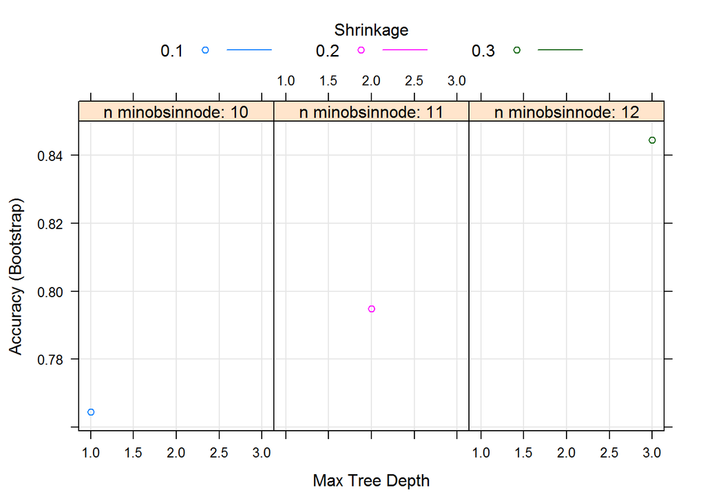

**4.)**

**a.) RESIDENTIAL BUILDING DATA SET**

-LASSO

```
##         1         2         3         4         5         6         7
## 1570.4679  172.9976 6142.4861 3060.5373 1623.3876  171.5494 1290.8313
##         8         9        10        11        12        13        14
##  857.9500 2178.5005 1808.8508 1892.1194 2269.3257 3590.7299 2280.1551
##        15        16        17        18        19        20        21
##  848.3952 2029.2069 1226.2982 1128.3405  805.6766 1523.9228  972.8350
##        22        23        24        25        26        27        28
## 2258.4986 1494.1397 1046.1108 1880.2084  485.8323 1048.6852  356.9717
##        29        30        31        32        33        34        35
## 1011.7923 1819.3115  285.2232 1122.4970  287.2196 2291.0631 1400.2479
##        36        37        38        39        40        41        42
##  665.2514  936.2586  169.6283  225.3482  945.7240 1044.2900  227.1922
##        43        44        45        46        47        48        49
## 1048.4195  590.7853  490.1745 1654.0075 1199.4312  451.0541 1478.3401
##        50        51        52        53        54        55        56
##  875.7875  728.1531  363.3529  959.9353  678.8768  529.8518  604.9967
##        57        58        59        60        61        62        63
##  432.1970  959.5789  917.0697  433.0273  525.2388 1089.3728  792.1414
##        64        65        66        67        68        69        70
##  516.7019  221.3633 1151.6905 1021.7041 1059.0017 1976.6910 2672.6205
##        71        72        73
## 1753.6681 1489.4720 1079.5575
```

-SVM-RADIAL

```
##         1         2         3         4         5         6         7
## 2208.5522  324.5309 5449.9992 3009.1772 1505.5209  339.0606 1401.8663
##         8         9        10        11        12        13        14
##  843.8953 2242.1722 1869.5683 1775.8490 2346.3857 3575.0236 2136.5077
##        15        16        17        18        19        20        21
## 2493.8770 2410.5602 1308.7729 1096.9234  927.9084 1568.8540 1027.0869
##        22        23        24        25        26        27        28
## 2101.7300 1343.1548 1118.9284 1960.2778  533.5843 1240.8987  385.3734
##        29        30        31        32        33        34        35
## 1014.5853 1965.2550  457.2516 1108.9047  333.9849 2364.2099 1152.6951
##        36        37        38        39        40        41        42
##  756.2688 1111.3488  304.7743  362.8944  917.7495 1003.8754  292.1046
##        43        44        45        46        47        48        49
## 1162.2336  575.0129  641.0071 1664.4342 1090.2944  571.1950 1471.1600
##        50        51        52        53        54        55        56
##  891.7366  722.2509  406.8809  738.7699 1038.6399  493.9777  555.9741
##        57        58        59        60        61        62        63
##  432.6023 1017.2395  953.0810  727.0982  665.4354  990.0247  719.0697
##        64        65        66        67        68        69        70
##  664.1468  338.2168 1297.8942  923.9184 2362.3133 2084.4518 2459.7279
##        71        72        73
## 1902.3233 1645.1012 1084.7205
```

```
##    Min. 1st Qu.  Median    Mean 3rd Qu.    Max.
##   292.1   665.4  1084.7  1287.4  1775.8  5450.0
```

-DECISION TREES

[output not shown]

[output not shown]

-RANDOM FOREST

```
##         1         2         3         4         5         6         7
## 1663.1450  134.0912 4576.5317 2223.4531 1209.2251  229.2182 1351.4763
##         8         9        10        11        12        13        14
##  692.2333 2285.3068 1609.1154 1316.9486 2735.7660 3090.8423 1697.8311
##        15        16        17        18        19        20        21
## 3671.6935 3369.9806 1107.2012 1100.0738  794.2470 1378.5600  969.9133
##        22        23        24        25        26        27        28
## 2420.8346 1406.7627 1119.4868 3094.7492  566.5357 1244.6424  287.8759
##        29        30        31        32        33        34        35
##  888.4734 1891.9542  414.8362 1070.9497  292.2479 1920.4135 1331.2119
##        36        37        38        39        40        41        42
##  591.3618 1300.2240  189.3130  276.9710  917.7523  851.9428  310.0853
##        43        44        45        46        47        48        49
## 1995.9134  706.3561  690.3180 1776.9875 1173.2261  728.7107 1481.1697
##        50        51        52        53        54        55        56
## 1218.8400  804.4076  757.8965 1756.9335 1254.0935 1153.1866  683.7474
##        57        58        59        60        61        62        63
##  741.3419 1706.1592 1108.6832  997.7489 1130.5300 1730.3732 1019.3424
##        64        65        66        67        68        69        70
## 1066.1960  393.7090 2368.4148 2650.6700 2987.1185 1688.6348 2077.4781
##        71        72        73
## 1344.1213 1767.8258 1147.9624
```

-SGB

```
##  [1] 1660.7003  662.9471 3959.1986 2897.2519 1660.7003  662.9471 1410.3213
##  [8] 1069.7061 1833.6737 1660.7003 1660.7003 1833.6737 3600.6986 1833.6737
## [15] 1833.6737 1660.7003 1410.3213 1069.7061  927.1709 1660.7003 1069.7061
## [22] 1833.6737 1660.7003 1069.7061 1660.7003  774.0209 1069.7061  662.9471
## [29] 1069.7061 1833.6737  662.9471 1069.7061  662.9471 1833.6737 1410.3213
## [36]  927.1709 1069.7061  662.9471  662.9471 1069.7061 1069.7061  662.9471
## [43] 1069.7061  774.0209  774.0209 1410.3213 1287.0105  662.9471 1660.7003
## [50] 1069.7061  927.1709  662.9471  927.1709  927.1709  662.9471  774.0209
## [57]  662.9471 1069.7061 1069.7061  774.0209  774.0209 1069.7061  927.1709
## [64]  774.0209  662.9471 1410.3213 1069.7061 2579.7223 1660.7003 2579.7223
## [71] 1660.7003 1410.3213 1069.7061
```

**b.)sport articles**

SVM

[output not shown]

[output cut: 20 more lines]

```
##   0   1
##  89 210
```

```
## Confusion Matrix and Statistics
##
##           Reference
## Prediction   0   1
##          0  73  16
##          1  36 174
##
##                Accuracy : 0.8261
##                  95% CI : (0.7783, 0.8673)
##     No Information Rate : 0.6355
##     P-Value [Acc > NIR] : 3.532e-13
##
##                   Kappa : 0.6093
##  Mcnemar's Test P-Value : 0.008418
##
##             Sensitivity : 0.6697
##             Specificity : 0.9158
##          Pos Pred Value : 0.8202
##          Neg Pred Value : 0.8286
##              Prevalence : 0.3645
##          Detection Rate : 0.2441
##    Detection Prevalence : 0.2977
##       Balanced Accuracy : 0.7928
##
##        'Positive' Class : 0
##
```

DECISION TREE

testing_dt_sportarticles$obj_subj<-as.factor(testing_dt_sportarticles$obj_subj) dectre_sportart <- rpart(obj_subj ~ ., data = training_dt_sportarticless, minbucket = 4,cp=0.01) prediction_dectre_sportart<-predict(dectre_sportart, testing_dt_sportarticles) prediction_dectre_sportart summary(predict(dectre_sportart, testing_dt_sportarticles)) confusionMatrix(prediction_dectre_sportart, testing_dt_sportarticles$obj_subj)

**c.)LAS VEGAS**

LAS VEGAS

#svm radial testing_lasvegas$Score<-as.factor(testing_lasvegas$Score) #çalışmıyor testing_lasvegas <- LasVegasTripAdvisorReviews_dataset[-data_partition_lasvegas ,] dectre_lasvegas<-rpart(Score~., data =training_lasvegas_dt, minbucket = 3,cp=0.01) testing_lasvegass<-testing_lasvegas[,-1] prediction_dectree_lasvegas<-predict(dectre_lasvegas, as.data.table(testing_lasvegass)) summary(predict(dectre_lasvegas, testing_lasvegas)) confusionMatrix(prediction_svm_lasvegas, testing_lasvegas$Score)

Everthing was the same but the codes did not work in las vegas prediction.

**5 CODES SECTION**

- From Second Part

RESIDENTIAL DATA SET

residential_building_dataset<-read_excel(“C:/Users/Merve/Documents/Residential_Building_Data_Set.xlsx”) sportarticles_dataset<-read_excel(“C:/Users/Merve/Documents/sportarticles.xls”) #50+ features #Y has categorical variable LasVegasTripAdvisorReviews_dataset<-read_excel(“C:/Users/Merve/Documents/LasVegasTripAdvisorReviews-Dataset.xls”) #Has some cetegorical & ordinal variables parkinsons<-‘C:/Users/Merve/Documents/parkinsons.txt’ parkinsons<-read.table(parkinsons,header=TRUE,sep = “,”) #Remove NA residential_building_dataset<- na.omit(residential_building_dataset) # Split the data into training and test set set.seed(135) training_samples <- residential_building_dataset$`V-9` %>% createDataPartition(p = 0.8, list = FALSE) #V-9 represents actual sales price, which is our output. train_residential_building_dataset<-residential_building_dataset[training_samples, ] train_residential_building_dataset=as.matrix(as.data.frame(lapply(train_residential_building_dataset, as.numeric))) train_residential_building_dataset<-as.data.frame(train_residential_building_dataset) test_residential_building_dataset<-residential_building_dataset[-training_samples, ] train_residential_building_dataset_withouty<-train_residential_building_dataset[,-108] train_residential_building_dataset_y<-train_residential_building_dataset[,108] dm_train_residential_building_dataset_withouty<-data.matrix(train_residential_building_dataset_withouty) dm_train_residential_building_dataset_y<-data.matrix(train_residential_building_dataset_y) *LASSO cv_lasso_train_residential_dataset<-cv.glmnet(dm_train_residential_building_dataset_withouty, dm_train_residential_building_dataset_y, alpha = 1, nfolds=10,type.measure = "mse") cv_lasso_train_residential_dataset # to find the best lambda using cross-validation fit the final model on the training data cv_bestlambda_train_residential <- glmnet(dm_train_residential_building_dataset_withouty,dm_train_residential_building_dataset_y, alpha=1,lambda=cv_lasso_train_residential_dataset$lambda.min) coef(cv_bestlambda_train_residential) plot(cv_lasso_train_residential_dataset,main=“LASSO Regression”)

*SUPPORT VECTOR MACHINES-BOTH RADIAL AND POLYNOMIAL dm_residential<-cbind(dm_train_residential_building_dataset_y,dm_train_residential_building_dataset_withouty) svm_radialbasis_residential <- svm(dm_train_residential_building_dataset_y ~ ., data =dm_residential,kernel=“radial”,cross=10) svm_radialbasis_residential svm_polynomial_residential <- svm(dm_train_residential_building_dataset_y ~ ., data = dm_residential,kernel = “polynomial”,cross = 10) svm_polynomial_residential

*DECISION TREE residential_decisiontree<-rpart(V.9~.,train_residential_building_dataset ,method=“class”) rpart.plot(residential_decisiontree,type=4,extra=100,trace=-1)

*RANDOM FOREST randomforest_residential<-randomForest(dm_train_residential_building_dataset_y~ . , data = train_residential_building_dataset,nodesize=5) randomforest_residential

*GBM

residential_boost=gbm(dm_train_residential_building_dataset_y ~ . ,data = train_residential_building_dataset,distribution = “gaussian”,n.trees = 10000,shrinkage = 0.01, interaction.depth = 4) summary(residential_boost)

- From Third Part

RESIDENTIAL DATA SET

*PENALIZED REGRESSION

train_residential_building_dataset<-residential_building_dataset[training_samples, ] test_residential_building_dataset<-residential_building_dataset[-training_samples, ] train_residential_building_dataset_withouty<-train_residential_building_dataset[,-108] train_residential_building_dataset_y<-train_residential_building_dataset[,108] test_residential_building_dataset_withouty<-test_residential_building_dataset[,-108] test_residential_building_dataset_y<-test_residential_building_dataset[,108] train_residential_building_dataset_y = as.matrix(as.data.frame(lapply(train_residential_building_dataset_y, as.numeric))) mygrid<-data.frame(lambda=c(2,3,4,5)) set.seed(42) lasso_residential<-caret::train(`V-9`~.,data=train_residential_building_dataset,method=“rqlasso”,tuneGrid=mygrid) lasso_residential plot(lasso_residential)

*SUPPORT VECTOR MACHINES-BOTH RADIAL AND POLYNOMIAL set.seed(3) tune_svm_residential_radial<-tune.svm(`V-9`~., data =train_residential_building_dataset, cost = 2^(2:4)) tune_svm_residential_radial summary(tune_svm_residential_radial) plot(tune_svm_residential_radial)

*DECISION TREES set.seed(3) tune_dectree_residential<-tune.rpart(`V-9`~., data =train_residential_building_dataset, minbucket = 2:5, cp=0.01:0.3) tune_dectree_residential summary(tune_dectree_residential)

*RANDOM FOREST require(randomForest) mygrid<-data.frame(mtry=c(2,3,4,5)) set.seed(42) tune__residential_randomforest<-caret::train(`V-9`~.,data=train_residential_building_dataset,method=“rf”,tuneGrid=mygrid) summary(tune__residential_randomforest) plot(tune__residential_randomforest)

*STOCHASTIC GRADIENT BOOSTING require(gbm) require(plyr) set.seed(42) mygrid<-data.frame(n.trees=c(2,3,4),interaction.depth= c(1,2,3),shrinkage=c(0.1,0.2,0.3),n.minobsinnode=c(10,10,10)) sgb_residential<-caret::train(`V-9`~.,data=train_residential_building_dataset,method=“gbm”,tuneGrid=mygrid) plot(sgb_residential)

- ENSEMBLE set.seed(40) require(ipred) require(plyr) require(e1071) #ens_residential<-caret::train(`V-9`~.,data=train_residential_building_dataset,method=“treebag”)

PARKINSONS CLASS IMBALANCE PART THAT WAS REVISED

require(ROSE) parkinsons<-‘C:/Users/Merve/Documents/parkinsons.txt’ parkinsons<-read.table(parkinsons,header=TRUE,sep = “,”) parkinsons<-parkinsons[,-1] parkinsons$status<-as.factor(parkinsons$status) table(parkinsons$status) prop.table(table(parkinsons$status)) data_balanced_over <- ovun.sample(status ~ ., data = training_parkinsons, method = “over”,N = 200)$data table(data_balanced_over$status)

- From Fourth Part

sport articles

SVM

svm_sportart <- svm(obj_subj ~ ., data = training_dt_sportarticless, cost = 4) prediction_svm_sportart<-predict(svm_sportart, testing_dt_sportarticles) testing_dt_sportarticles$obj_subj<-as.factor(testing_dt_sportarticles$obj_subj) summary(predict(svm_sportart, testing_dt_sportarticles)) confusionMatrix(prediction_svm_sportart, testing_dt_sportarticles$obj_subj)

DECISION TREE

dectre_sportart <- rpart(obj_subj ~ ., data = training_dt_sportarticless, minbucket = 4,cp=0.01) prediction_dectre_sportart<-predict(dectre_sportart, testing_dt_sportarticles) testing_dt_sportarticles$obj_subj<-as.factor(testing_dt_sportarticles$obj_subj) summary(predict(dectre_sportart, testing_dt_sportarticles)) confusionMatrix(prediction_dectre_sportart, testing_dt_sportarticles$obj_subj)

LAS VEGAS

svm radial testing_lasvegas$Score<-as.factor(testing_lasvegas$Score)

testing_lasvegas <- LasVegasTripAdvisorReviews_dataset[-data_partition_lasvegas ,] dectre_lasvegas<-rpart(Score~., data =training_lasvegas_dt, minbucket = 3,cp=0.01) testing_lasvegass<-testing_lasvegas[,-1] prediction_dectree_lasvegas<-predict(dectre_lasvegas, as.data.table(testing_lasvegass)) summary(predict(dectre_lasvegas, testing_lasvegas)) confusionMatrix(prediction_svm_lasvegas, testing_lasvegas$Score)

Everthing was the same but the codes did not work in las vegas prediction.